# Project 1

Ruiyu ZHANG

9/20/2022

# Topic

In this project, the topic is Exploratory Data Analysis of History of Philosophy

Project title: Relationships of Philosophy Sentences and Other Factors.

This Project is conducted by Ruiyu Zhang

Project Summary: This report analyzed The History of Philosophy dataset for the purpose of finding potential relationships between philosophy sentence lengths and factors like publication date, author, and school. Along the way, interesting findings on the history of philosophy are also reported. And, at the end stage, relationships of philosophy sentences with different authors and their corresponding frequencies of words are represented by wordclouds plots to produce a clearer view of frequencies of words in sentences.

# Method

I will follow the following steps: 1. Import the data 2. Clean the data 3. Process the data 4. Visualize the data 5. Conclude the findings

## 1. Import the data

First of all, I imported the dataset downloaded from Kaggle. By importing and explore the first look of the data, I see that there are 11 total columns, with only three columns of integer types and the rest are character types.

```
## 'data.frame':    360808 obs. of  11 variables:
##  $ title                    : chr  "Plato - Complete Works" "Plato - Complete Works" "Plato - Complete Works" "Plato - Complete Works" ...
##  $ author                   : chr  "Plato" "Plato" "Plato" "Plato" ...
##  $ school                   : chr  "plato" "plato" "plato" "plato" ...
##  $ sentence_spacy           : chr  " What's new, Socrates, to make you leave your usual haunts in the Lyceum and spend your time here by the king archon's court?" "Surely you are not prosecuting anyone before the king archon as I am?" "The Athenians do not call this a prosecution but an indictmen…
##  $ sentence_str             : chr  " What's new, Socrates, to make you leave your usual haunts in the Lyceum and spend your time here by the king archon's court?" "Surely you are not prosecuting anyone before the king archon as I am?" "The Athenians do not call this a prosecution but an indictmen…
##  $ original_publication_date: int  -350 -350 -350 -350 -350 -350 -350 -350 -350 -350 ...
##  $ corpus_edition_date      : int  1997 1997 1997 1997 1997 1997 1997 1997 1997 1997 ...
##  $ sentence_length          : int  125 69 74 21 101 34 43 35 33 147 ...
##  $ sentence_lowered         : chr  " what's new, socrates, to make you leave your usual haunts in the lyceum and spend your time here by the king archon's court?" "surely you are not prosecuting anyone before the king archon as i am?" "the athenians do not call this a prosecution but an indictmen…
##  $ tokenized_txt            : chr  "['what', 'new', 'socrates', 'to', 'make', 'you', 'leave', 'your', 'usual', 'haunts', 'in', 'the', 'lyceum', 'an"| __truncated__ "['surely', 'you', 'are', 'not', 'prosecuting', 'anyone', 'before', 'the', 'king', 'archon', 'as', 'am']" "['the', 'athenians', 'do',…
##  $ lemmatized_str           : chr  "   what be new , Socrates , to make -PRON- leave -PRON- usual haunt in the Lyceum and spend -PRON- time here by"| __truncated__ " surely -PRON- be not prosecute anyone before the king archon as -PRON- be ?" " the Athenians do not call this a prosecution but an …
```

```r
library(tidyverse)
library(devtools)
```

```r
library(ggplot2)
library(dplyr)
library(tidyr)
library(ggpubr)
library(wordcloud)
library(RColorBrewer)
library(wordcloud2)
library(tm)
```

## 2. Clean the data

Data is already pre-processed before downloading from Kaggle. The only data cleaning I need to do is to subset the data. Here, since my interest in this report is to explore relationships between philosophy sentence lengths and factors like publication date, author, and school. I subset the data to 6 columns of what I needed.

|  | title | author | school | original_publication_date | corpus_edition_date | sentence_length |
| --- | --- | --- | --- | --- | --- | --- |
| 1 | Plato - Complete Works | Plato | plato | -350 | 1997 | 125 |
| 2 | Plato - Complete Works | Plato | plato | -350 | 1997 | 69 |
| 3 | Plato - Complete Works | Plato | plato | -350 | 1997 | 74 |
| 4 | Plato - Complete Works | Plato | plato | -350 | 1997 | 21 |
| 5 | Plato - Complete Works | Plato | plato | -350 | 1997 | 101 |
| 6 | Plato - Complete Works | Plato | plato | -350 | 1997 | 34 |

```
## [1] "title"                     "author"
## [3] "school"                    "original_publication_date"
## [5] "corpus_edition_date"       "sentence_length"
```

## 3. Process and mine the data

In this section, I will first evaluate the means of sentence length grouped by schools and authors.

| school | author | sentence_length_mean |
| --- | --- | --- |
| analytic | Kripke | 119.02508 |
| analytic | Lewis | 109.71761 |
| analytic | Moore | 167.25491 |
| analytic | Popper | 139.54510 |
| analytic | Quine | 121.64343 |
| analytic | Russell | 146.29667 |
| analytic | Wittgenstein | 84.88377 |
| aristotle | Aristotle | 153.22495 |
| capitalism | Keynes | 196.65406 |
| capitalism | Ricardo | 186.25275 |

[output cut: 26 more lines]

From the above findings, I see that means of sentence lengths from each group of (school, author) are fairly around 100 to 200; in other words, there is no big difference among groups. It is worth to notice that (analytic, Wittgenstein) has the lowest mean of sentence length, which is only 84.884.

Next, let’s evaluate data grouped by school, author, and title.

| school | author | title | sentence_length_mean |
| --- | --- | --- | --- |
| analytic | Kripke | Naming And Necessity | 120.56583 |
| analytic | Kripke | Philosophical Troubles | 118.60349 |
| analytic | Lewis | Lewis - Papers | 109.71761 |
| analytic | Moore | Philosophical Studies | 167.25491 |
| analytic | Popper | The Logic Of Scientific Discovery | 139.54510 |
| analytic | Quine | Quintessence | 121.64343 |
| analytic | Russell | The Analysis Of Mind | 142.63564 |
| analytic | Russell | The Problems Of Philosophy | 154.54103 |
| analytic | Wittgenstein | On Certainty | 79.37752 |
| analytic | Wittgenstein | Philosophical Investigations | 83.57725 |

[output cut: 49 more lines]

Now, when I dive in deeper of the dataset by grouping by three columns, school, author, and title respectively, I see three groups with lower than 100 means: (analytic,Wittgenstein,On Certainty),(analytic,Wittgenstein,Philosophical Investigations),(nietzsche, Nietzsche, Thus Spake Zarathustra).Other than the three groups, means are failry around 100 to 200. By looking at group means, we do not find any significant result of difference between sentence length among different groups of (school, author) or (school, author, title).

Since one of the goals is to examine the relationships between sentence length with other factors. Let’s check the correlation coefficients:

```
## [1] 0.06739653
```

```
## [1] 0.01663432
```

By above correlation coefficient, we see that both sentence length and corpus edition date and sentence length and original publication date is actually weakly correlated. In other words, we can not find a strong positive or negative relationship between those two factors. After examining the relationship between two numerical features. Let’s process Kruskal-Wallis test to find if there is any relationship between categorical features, such as school, author, title with sentence length. The null hypothesis will be the medians of groups are equal, and the alternative hypothesis is that at least one of the group has different median.

```
##
##  Kruskal-Wallis rank sum test
##
## data:  sentence_length by school
## Kruskal-Wallis chi-squared = 22436, df = 12, p-value < 2.2e-16
```

```
##
##  Kruskal-Wallis rank sum test
##
## data:  sentence_length by author
## Kruskal-Wallis chi-squared = 31272, df = 35, p-value < 2.2e-16
```

```
##
##  Kruskal-Wallis rank sum test
##
## data:  sentence_length by title
## Kruskal-Wallis chi-squared = 34909, df = 58, p-value < 2.2e-16
```

As the p-values for all three KW rank sum test are less than the significance level 0.05, we reject the null and conclude that medians of sentence lengths are diffrent from group schoo, author, and title. By now, we have examine both numerical and categorical relationship with sentence length. We find that there is no particular correlation between original publication date and sentence length and edition date to sentence length. But, it is worth to mention that from KW test we found medians of sentence lengths are different among schools, authors, titles.

## 4. Visualize the data

Let’s take a closer look of the dataset with Categorical Features:

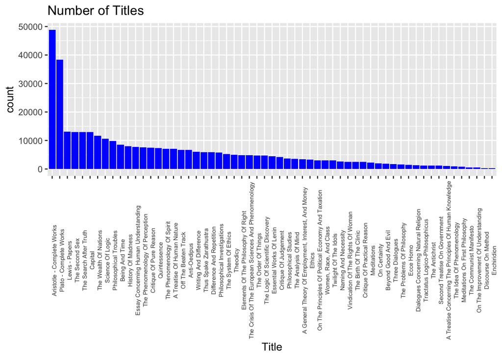

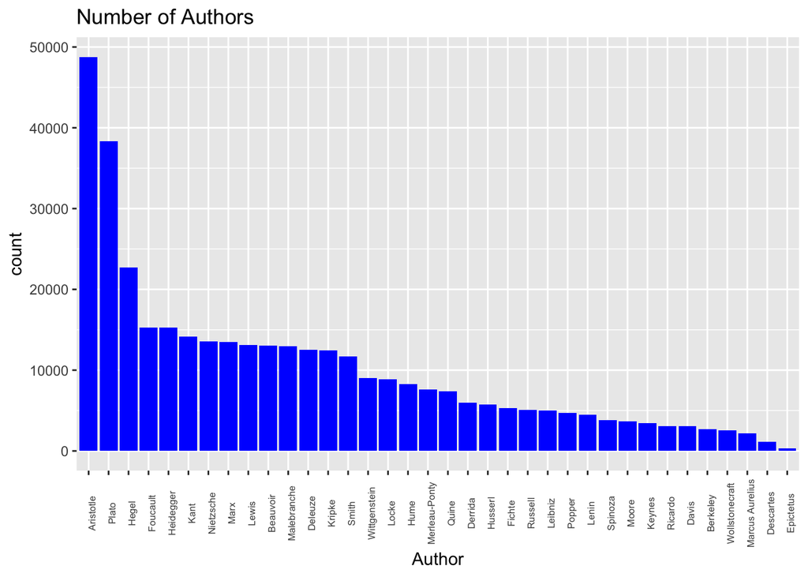

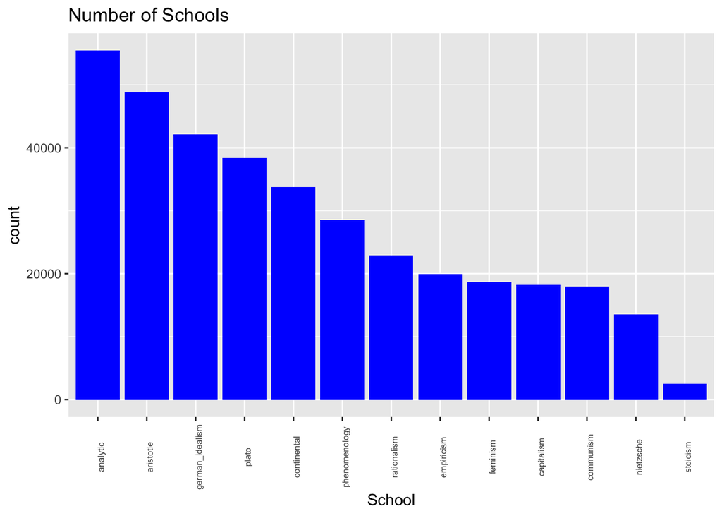

From the above categorical data plots, I am able to visualize the counts of different title, author, and school in the data. As for title, we have the most entries from Aristotle-Complete Works, following by Plato-Complete Works on the second. As for author, we have the similar result, where Aristotle ranked the first and Plato the second. As for number of school, we have Analytic the most and Aristotle the second.

Next, let’s take a closer look at the dataset with numerical features:

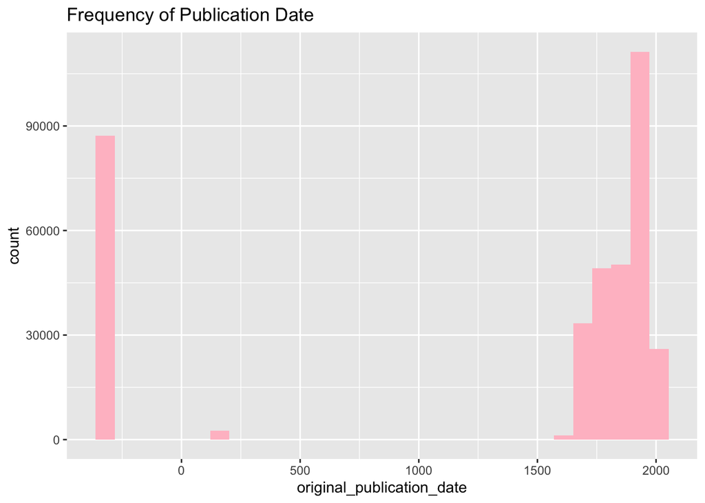

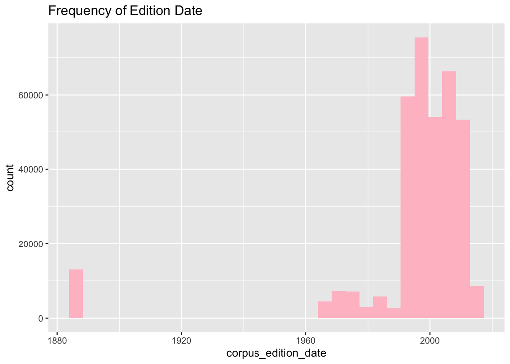

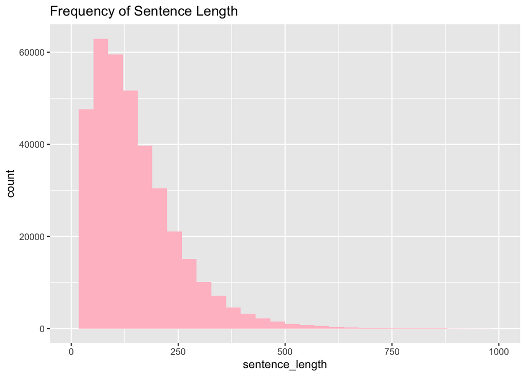

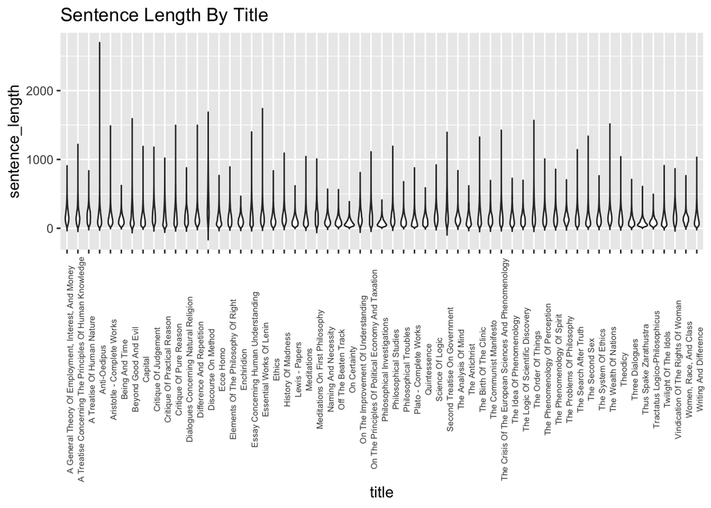

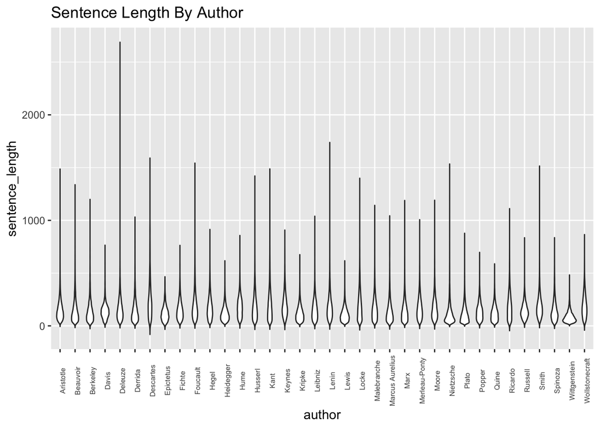

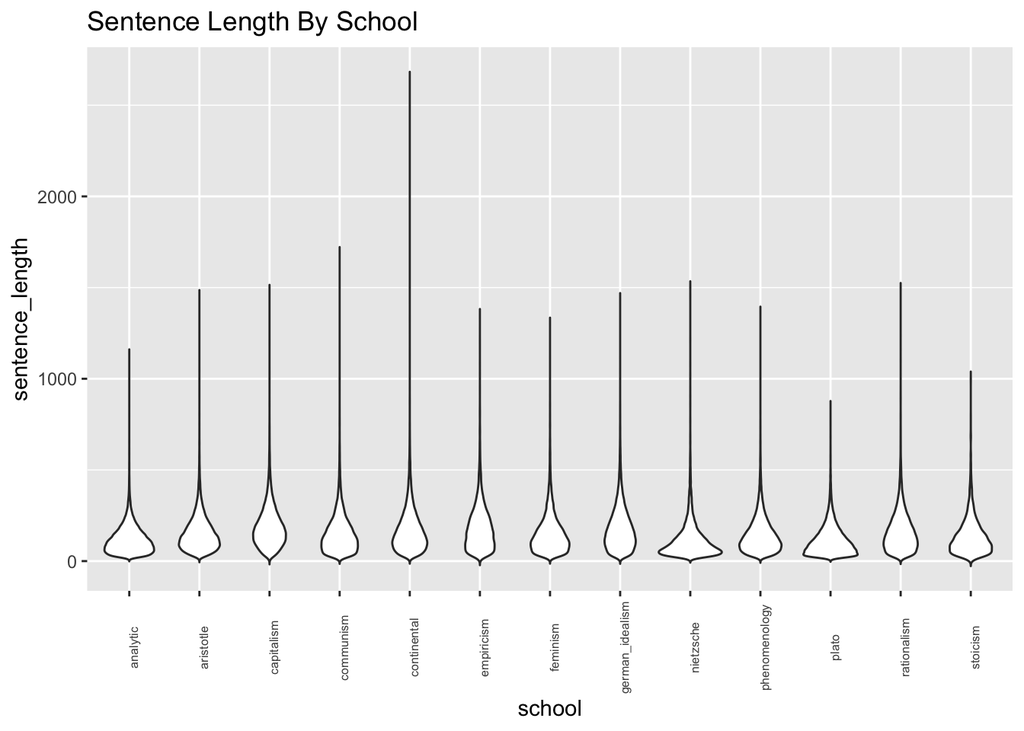

From the above numerical data plots, I am able to visualize most of philosophy sentences were originally published from 1500 to 2000, edited from 1980 to 2020. Besides, I see a right-skewed histogram of sentences length, most of sentences length go from 0 - 250.

## 5. Word Clouds

In this section, I will examine the most frequent words by word clouds and frequency barplot. Since the whole dataset is too large and unable to generate word clouds due to vector memory reasons. I will subset the data by the author from “Number of Authors” plot developed in part 4. They will be Plato, Hegel, and Foucault.

I skipped the Aristotle with most counts because it is unable to run because of vector memory reason due to subset too large.

The following is Plato subset:

|  | word | freq |
| --- | --- | --- |
| one | one | 4951 |
| will | will | 3047 |
| things | things | 2941 |
| say | say | 2672 |
| now | now | 2446 |
| said | said | 2331 |
| must | must | 2272 |
| good | good | 2263 |
| think | think | 2177 |
| man | man | 2076 |

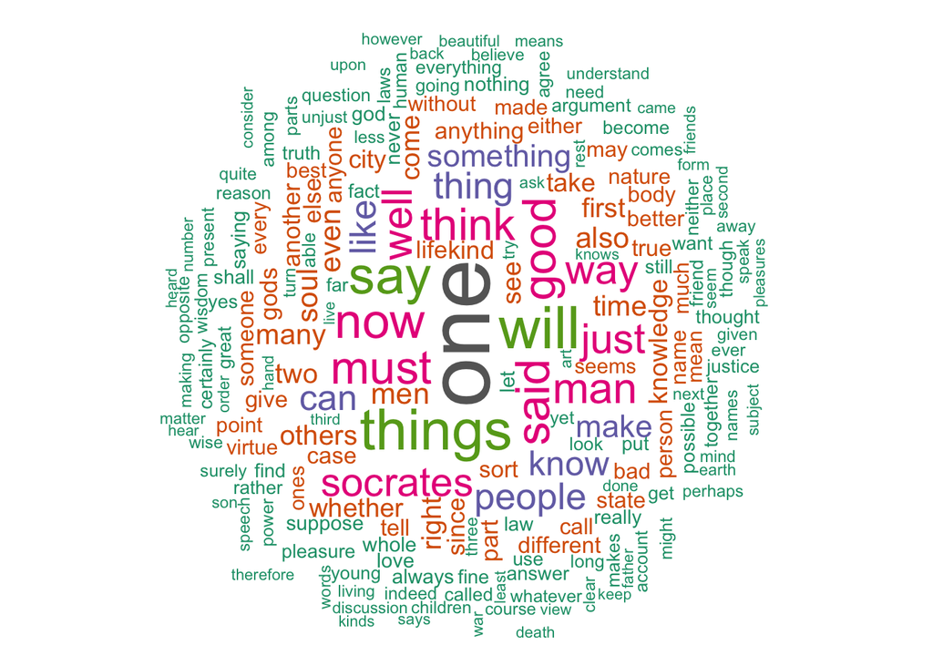

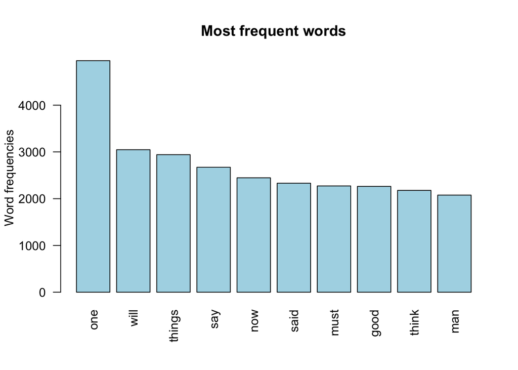

Most frequent words for Plato are “one”, “will”, and “things”.

The following is Hegel subset:

|  | word | freq |
| --- | --- | --- |
| one | one | 3198 |
| self | self | 3183 |
| consciousness | consciousness | 2479 |
| concept | concept | 1958 |
| therefore | therefore | 1953 |
| also | also | 1799 |
| form | form | 1798 |
| existence | existence | 1771 |
| content | content | 1679 |
| first | first | 1630 |

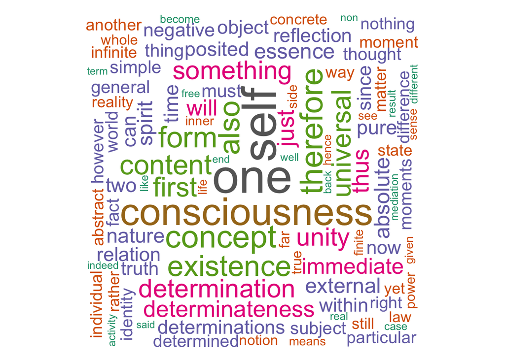

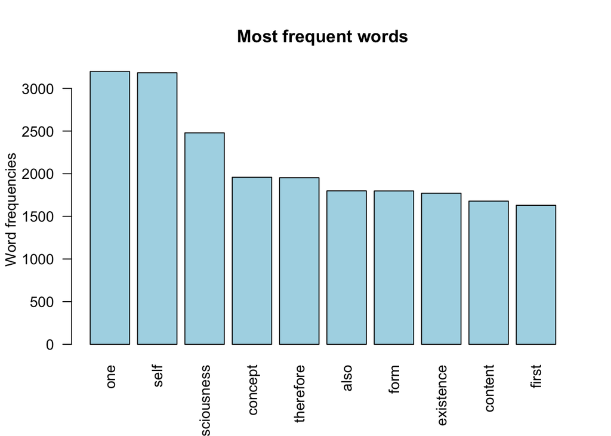

The following is Foucault subset:

|  | word | freq |
| --- | --- | --- |
| madness | madness | 2043 |
| one | one | 1973 |
| language | language | 1136 |
| form | form | 1012 |
| can | can | 1011 |
| century | century | 967 |
| nature | nature | 916 |
| knowledge | knowledge | 897 |
| man | man | 892 |
| order | order | 803 |

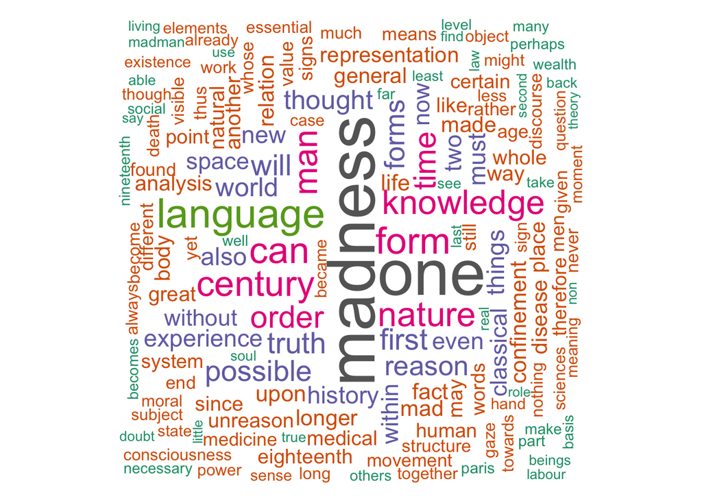

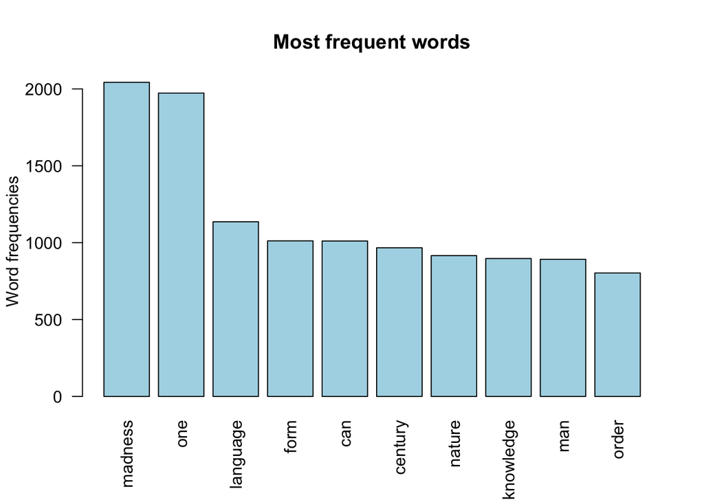

Most frequent words for Foucault are “madness”, “one”, “language”.